# Case 3 Medical text categorization

Tony Kuitunen  
1503242  
Cognitive Systems for Health Technology Applications  
24.2.2018  
Helsinki Metropolia University of Applied Sciences

#### Task

Task is to use recurrent and convolutional neural networks to create a classifier for a collection of medical abstracts extracted from MEDLINE, the online medical information database.

```python
from keras.preprocessing.text import Tokenizer
from keras.preprocessing.sequence import pad_sequences
from keras.utils.np_utils import to_categorical
from keras.models import Sequential
from keras import callbacks
from keras.layers import Flatten, Dense, Embedding, Conv1D, LSTM, Dropout, MaxPooling1D, Activation, BatchNormalization
from keras import regularizers

from sklearn.metrics import accuracy_score, precision_score, f1_score, confusion_matrix
from sklearn.metrics import classification_report, recall_score

import matplotlib.pyplot as plt
import numpy as np
import os
import time
```

# Preprocess

#### Process raw data

- Make a list of every label
- There will be 23 labels

Based on listing 6.8 (p. 189) Chollet: Deep Learning with Python, 2018.

```python
ohsumed_dir = 'ohsumed-first-20000-docs/'
train_dir = os.path.join(ohsumed_dir, 'training')

labels = []
texts = []

# Generate a list L = ['C01', 'C02, ..., 'C023']
L = ['C{:02}'.format(n) for n in range(1, 23 + 1)]
for label_type in L:
    dir_name = os.path.join(train_dir, label_type)
    for fname in os.listdir(dir_name):
        f = open(os.path.join(dir_name, fname))
        texts.append(f.read())
        f.close()
        i = L.index(label_type)
        labels.append(i)
```

#### Tokenize the text of the raw data

```python
maxlen = 60
max_words = 10000

tokenizer = Tokenizer(num_words = max_words)
tokenizer.fit_on_texts(texts)
sequences = tokenizer.texts_to_sequences(texts)

word_index = tokenizer.word_index
print('Found %s unique tokens' % len(word_index))
```

```
Found 30857 unique tokens
```

#### Shape the data and labels

```python
data = pad_sequences(sequences, maxlen = maxlen)

labels = np.asarray(labels)
one_hot_labels = to_categorical(labels)


print('Shape of data tensor:', data.shape)
print('Shape of labels tensor:', one_hot_labels.shape)
```

```
Shape of data tensor: (10433, 60)
Shape of labels tensor: (10433, 23)
```

#### Shuffle the data and labels

- Shuffle labels and data the sameway

```python
indices = np.arange(data.shape[0])
np.random.shuffle(indices)
data = data[indices]
labels = labels[indices]
one_hot_labels = one_hot_labels[indices]
```

```python
print(data[indices[512]])
print(texts[indices[512]])
```

```
[9518 2549 2057   28 2072    2  110  420    1 3103  755    2    1  837 6758
  481   15 2644 8255  420  488  381   12  402   34  218   14    8    6  420
 4527   52  843 9518 2549  494    5    7 2644 8255  420  488   78   21   87
    6  172 2072    2    1  420  249    5 1012 1117    3  399  650 1304  120]
Components of delay time in suspected acute myocardial infarction with particular emphasis on patient delay.
 Two hundred and thirty-four patients admitted to a coronary care unit (CCU) were interviewed a few days after arrival in hospital to determine reasons for patient delay and the various components of total delay time from onset of symptoms to arrival in CCU.
 Of the three major components of delay, decision time (time from onset of symptoms to decision to go to hospital), and hospital procedure time (time from arrival in hospital to arrival in the CCU), were of the same magnitude, 1 h 15 min and 1 h 30 min (median), whereas the median time for preparati…
 Decision time appeared to be similar in patients with confirmed and non-confirmed acute myocardial infarction (AMI) and was not associated with intensity of pain or infarct size.
 Half of the patients hesitated to go to hospital, which resulted in a prolonged decision delay (3 h).
 It is concluded that patient indecision to seek medical help is the most important reason for delay in hospital arrival in patients with suspected AMI.
```

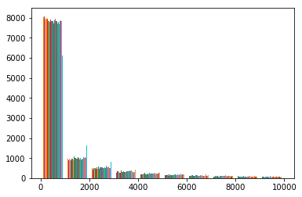

```python
plt.hist(data)
plt.show()
```

## Build the 1st model

```python
#kernel_regularizer=regularizers.l1(0.01)
model = Sequential()
model.add(Embedding(max_words, 64, input_length=maxlen))

model.add(Conv1D(32, 3, kernel_regularizer=regularizers.l1(0.01)))
model.add(BatchNormalization())
model.add(Dropout(0.1))
model.add(MaxPooling1D(2))

model.add(Conv1D(64, 3, kernel_regularizer=regularizers.l1(0.01)))
model.add(BatchNormalization())
model.add(Dropout(0.2))
model.add(MaxPooling1D(2))


model.add(Flatten())
model.add(Dense(1024, activation = 'relu', kernel_regularizer=regularizers.l1(0.01)))
model.add(Dropout(0.3))
model.add(Dense(256, activation = 'relu'))
model.add(Dropout(0.3))
#model.add(Dense(128, activation = 'relu'))
#model.add(Dense(64, activation = 'relu'))
model.add(Dense(len(L), activation = 'softmax'))

from keras import optimizers
rmsprop = optimizers.RMSprop(lr=0.003)


model.compile(optimizer = rmsprop,
             loss = 'categorical_crossentropy',
             metrics = ['accuracy'])

model.summary()
```

```
_________________________________________________________________
Layer (type)                 Output Shape              Param #
=================================================================
embedding_56 (Embedding)     (None, 60, 64)            640000
_________________________________________________________________
conv1d_95 (Conv1D)           (None, 58, 32)            6176
_________________________________________________________________
batch_normalization_54 (Batc (None, 58, 32)            128
_________________________________________________________________
dropout_36 (Dropout)         (None, 58, 32)            0
_________________________________________________________________
max_pooling1d_80 (MaxPooling (None, 29, 32)            0
_________________________________________________________________
conv1d_96 (Conv1D)           (None, 27, 64)            6208
_________________________________________________________________
batch_normalization_55 (Batc (None, 27, 64)            256
_________________________________________________________________
dropout_37 (Dropout)         (None, 27, 64)            0
_________________________________________________________________
max_pooling1d_81 (MaxPooling (None, 13, 64)            0
_________________________________________________________________
flatten_43 (Flatten)         (None, 832)               0
_________________________________________________________________
dense_156 (Dense)            (None, 1024)              852992
_________________________________________________________________
dropout_38 (Dropout)         (None, 1024)              0
_________________________________________________________________
dense_157 (Dense)            (None, 256)               262400
_________________________________________________________________
dropout_39 (Dropout)         (None, 256)               0
_________________________________________________________________
dense_158 (Dense)            (None, 23)                5911
=================================================================
Total params: 1,774,071
Trainable params: 1,773,879
Non-trainable params: 192
_________________________________________________________________
```

```python
#model.fit(data, one_hot_labels,epochs = 1,batch_size = 32,validation_split = 0.2)
```

#### Train the model

- Make a callback after each epoch and save the model only if it has gotten better

```python
filepath = 'saves\\case3_first.hdf5'
modelcheckpoint = callbacks.ModelCheckpoint(filepath, monitor='val_acc', verbose=0, save_best_only=True, save_weights_only=False, mode='auto', period=1)

t1 = time.time()
history = model.fit(data, one_hot_labels,
                   epochs = 60,
                   batch_size = 128,
                   validation_split = 0.2,
                   verbose = 0,
                   callbacks=[modelcheckpoint])
t2 = time.time()
modeltime=t2-t1
print('Elapsed time: {:.2f} seconds'.format((t2-t1)))
```

```
Elapsed time: 833.89 seconds
```

#### Plot the results in a graph

- Make a function to easen this process later

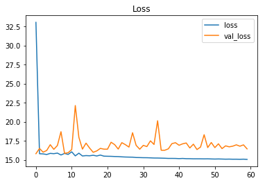

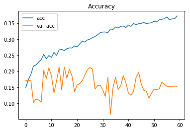

```python
def plotHistory(history):
    loss = history.history['loss']
    val_loss = history.history['val_loss']
    acc = history.history['acc']
    val_acc = history.history['val_acc']
    epoch = history.epoch

    plt.plot(epoch,loss)
    plt.plot(epoch,val_loss)
    plt.legend(['loss','val_loss'])
    plt.title("Loss")
    plt.show()

    plt.plot(epoch,acc)
    plt.plot(epoch,val_acc)
    plt.legend(['acc','val_acc'])
    plt.title("Accuracy")
    plt.show()

plotHistory(history)
```

## Build 2nd model

- Make use of LSTM RNN network rather than 1D convolutional network
- Make word embeddings

```python
#kernel_regularizer=regularizers.l1(0.01)
lmodel = Sequential()
lmodel.add(Embedding(max_words, 92, input_length=maxlen))

lmodel.add(LSTM(92, dropout=0.2, recurrent_dropout=0.2))
lmodel.add(Dense(64, activation = 'relu', kernel_regularizer=regularizers.l1(0.01)))
lmodel.add(Dropout(0.3))
lmodel.add(Dense(len(L), activation = 'softmax'))

from keras import optimizers
rmsprop = optimizers.RMSprop()


lmodel.compile(optimizer = rmsprop,
             loss = 'categorical_crossentropy',
             metrics = ['accuracy'])

lmodel.summary()
```

```
_________________________________________________________________
Layer (type)                 Output Shape              Param #
=================================================================
embedding_57 (Embedding)     (None, 60, 92)            920000
_________________________________________________________________
lstm_8 (LSTM)                (None, 92)                68080
_________________________________________________________________
dense_159 (Dense)            (None, 64)                5952
_________________________________________________________________
dropout_40 (Dropout)         (None, 64)                0
_________________________________________________________________
dense_160 (Dense)            (None, 23)                1495
=================================================================
Total params: 995,527
Trainable params: 995,527
Non-trainable params: 0
_________________________________________________________________
```

```python
#lmodel.fit(data, one_hot_labels,epochs = 1,batch_size = 64,validation_split = 0.2)
```

```python
lfilepath = 'saves\\case3_second.hdf5'
lmodelcheckpoint = callbacks.ModelCheckpoint(lfilepath, monitor='val_acc', verbose=0, save_best_only=True, save_weights_only=False, mode='auto', period=1)

t1 = time.time()
lhistory = lmodel.fit(data, one_hot_labels,
                    epochs = 60,
                    batch_size = 128,
                    validation_split = 0.2,
                    verbose = 0,
                    callbacks=[lmodelcheckpoint])
t2 = time.time()
lmodeltime=t2-t1
print('Elapsed time: {:.2f} seconds'.format((t2-t1)))
```

```
Elapsed time: 2318.91 seconds
```

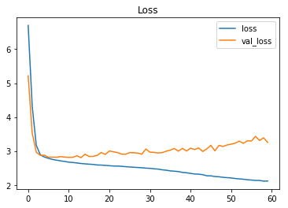

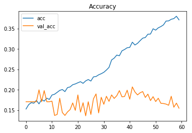

```python
plotHistory(lhistory)
```

## Build model using both

```python
#kernel_regularizer=regularizers.l1(0.01)
bmodel = Sequential()

bmodel.add(Embedding(max_words, 92, input_length=maxlen))
bmodel.add(Conv1D(64, 3, activation='relu', input_shape=(100, 100)))
bmodel.add(Conv1D(64, 3, activation='relu'))
bmodel.add(MaxPooling1D(3))
bmodel.add(Conv1D(128, 3, activation='relu'))
bmodel.add(Conv1D(128, 3, activation='relu'))
bmodel.add(MaxPooling1D(3))

bmodel.add(LSTM(92, dropout=0.2, recurrent_dropout=0.2))
bmodel.add(Dense(64, activation = 'relu', kernel_regularizer=regularizers.l1(0.01)))
bmodel.add(Dropout(0.3))
bmodel.add(Dense(len(L), activation = 'softmax'))

from keras import optimizers
rmsprop = optimizers.RMSprop()


bmodel.compile(optimizer = rmsprop,
             loss = 'categorical_crossentropy',
             metrics = ['accuracy'])

bmodel.summary()
```

```
_________________________________________________________________
Layer (type)                 Output Shape              Param #
=================================================================
embedding_58 (Embedding)     (None, 60, 92)            920000
_________________________________________________________________
conv1d_97 (Conv1D)           (None, 58, 64)            17728
_________________________________________________________________
conv1d_98 (Conv1D)           (None, 56, 64)            12352
_________________________________________________________________
max_pooling1d_82 (MaxPooling (None, 18, 64)            0
_________________________________________________________________
conv1d_99 (Conv1D)           (None, 16, 128)           24704
_________________________________________________________________
conv1d_100 (Conv1D)          (None, 14, 128)           49280
_________________________________________________________________
max_pooling1d_83 (MaxPooling (None, 4, 128)            0
_________________________________________________________________
lstm_9 (LSTM)                (None, 92)                81328
_________________________________________________________________
dense_161 (Dense)            (None, 64)                5952
_________________________________________________________________
dropout_41 (Dropout)         (None, 64)                0
_________________________________________________________________
dense_162 (Dense)            (None, 23)                1495
=================================================================
Total params: 1,112,839
Trainable params: 1,112,839
Non-trainable params: 0
_________________________________________________________________
```

```python
bfilepath = 'saves\\case3_three.hdf5'
bmodelcheckpoint = callbacks.ModelCheckpoint(bfilepath, monitor='val_acc', verbose=0, save_best_only=True, save_weights_only=False, mode='auto', period=1)

t1 = time.time()
bhistory = bmodel.fit(data, one_hot_labels,
                    epochs = 60,
                    batch_size = 128,
                    validation_split = 0.2,
                    verbose = 0,
                    callbacks=[bmodelcheckpoint])
t2 = time.time()
bmodeltime=t2-t1
print('Elapsed time: {:.2f} seconds'.format((t2-t1)))
```

```
Elapsed time: 1082.09 seconds
```

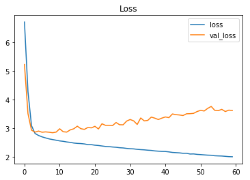

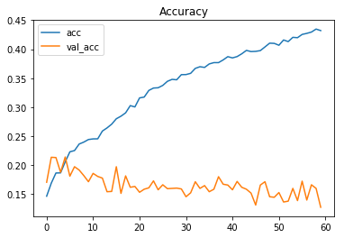

```python
plotHistory(bhistory)
```

## Metrics results and comparison

#### take test dataset

```python
ohsumed_dir = 'ohsumed-first-20000-docs/'
test_dir = os.path.join(ohsumed_dir, 'test')

test_labels = []
test_texts = []

# Generate a list L = ['C01', 'C02, ..., 'C023']
L = ['C{:02}'.format(n) for n in range(1, 23 + 1)]
for label_type in L:
    dir_name = os.path.join(test_dir, label_type)
    for fname in os.listdir(dir_name):
        f = open(os.path.join(dir_name, fname))
        test_texts.append(f.read())
        f.close()
        i = L.index(label_type)
        test_labels.append(i)

tokenizer = Tokenizer(num_words = max_words)
tokenizer.fit_on_texts(test_texts)
test_sequences = tokenizer.texts_to_sequences(test_texts)

test_word_index = tokenizer.word_index
test_data = pad_sequences(test_sequences, maxlen = maxlen)

test_labels = np.asarray(test_labels)

print('Shape of data tensor:', data.shape)
print('Shape of labels tensor:', one_hot_labels.shape)
```

```
Shape of data tensor: (10433, 60)
Shape of labels tensor: (10433, 23)
```

#### Make predictions

```python
from keras import models

# Calculate the predictions
predictions = model.predict(test_data)
y_pred = np.argmax(predictions, axis = 1)

#Try loading for example LSTM model from memory at the point it had best val_acc
lmodel2 = models.load_model(lfilepath)
lpredictions2 = lmodel2.predict(test_data)
ly_pred2 = np.argmax(lpredictions2, axis = 1)

#calculate predictions based on the last epoch
lpredictions = lmodel.predict(test_data)
ly_pred = np.argmax(lpredictions, axis = 1)

bpredictions = bmodel.predict(test_data)
by_pred = np.argmax(bpredictions, axis = 1)
```

```python
bmodel2 = models.load_model(bfilepath)
bpredictions2 = bmodel2.predict(test_data)
by_pred2 = np.argmax(bpredictions2, axis = 1)
```

http://scikit-learn.org/stable/modules/model_evaluation.html

#### Classification results per class

- First off is the 1D-convolutional model

```python
print(classification_report(test_labels, y_pred))
```

```
             precision    recall  f1-score   support

          0       0.04      0.03      0.03       506
          1       0.00      0.00      0.00       233
          2       0.00      0.00      0.00        70
          3       0.12      0.15      0.13      1467
          4       0.00      0.00      0.00       429
          5       0.07      0.04      0.05       632
          6       0.00      0.00      0.00       146
          7       0.04      0.02      0.02       600
          8       0.00      0.00      0.00       129
          9       0.00      0.00      0.00       941
         10       0.00      0.00      0.00       202
         11       0.00      0.00      0.00       548
         12       0.00      0.00      0.00       386
         13       0.14      0.02      0.03      1301
         14       0.00      0.00      0.00       320
         15       0.00      0.00      0.00       228
         16       0.04      0.00      0.01       348
         17       0.03      0.17      0.05       400
         18       0.00      0.00      0.00       191
         19       0.03      0.00      0.01       695
         20       0.04      0.02      0.02       717
         21       0.00      0.00      0.00        91
         22       0.17      0.55      0.26      2153

avg / total       0.07      0.12      0.07     12733
```

- second is the LSTM model

```python
print(classification_report(test_labels, ly_pred))
```

```
             precision    recall  f1-score   support

          0       0.00      0.00      0.00       506
          1       0.00      0.00      0.00       233
          2       0.00      0.00      0.00        70
          3       0.12      0.08      0.09      1467
          4       0.00      0.00      0.00       429
          5       0.05      0.01      0.02       632
          6       0.00      0.00      0.00       146
          7       0.05      0.01      0.02       600
          8       0.00      0.00      0.00       129
          9       0.09      0.03      0.04       941
         10       0.00      0.00      0.00       202
         11       0.03      0.01      0.01       548
         12       0.00      0.00      0.00       386
         13       0.11      0.08      0.10      1301
         14       0.00      0.00      0.00       320
         15       0.00      0.00      0.00       228
         16       0.00      0.00      0.00       348
         17       0.03      0.12      0.05       400
         18       0.00      0.00      0.00       191
         19       0.06      0.14      0.08       695
         20       0.06      0.12      0.08       717
         21       0.00      0.00      0.00        91
         22       0.17      0.42      0.24      2153

avg / total       0.07      0.11      0.08     12733
```

- Try the LSTM with loaded model from memory that had the best validation accuracy

```python
print(classification_report(test_labels, ly_pred2))
```

```
             precision    recall  f1-score   support

          0       0.00      0.00      0.00       506
          1       0.00      0.00      0.00       233
          2       0.00      0.00      0.00        70
          3       0.12      0.09      0.10      1467
          4       0.00      0.00      0.00       429
          5       0.00      0.00      0.00       632
          6       0.00      0.00      0.00       146
          7       0.00      0.00      0.00       600
          8       0.00      0.00      0.00       129
          9       0.00      0.00      0.00       941
         10       0.00      0.00      0.00       202
         11       0.00      0.00      0.00       548
         12       0.00      0.00      0.00       386
         13       0.11      0.11      0.11      1301
         14       0.00      0.00      0.00       320
         15       0.00      0.00      0.00       228
         16       0.00      0.00      0.00       348
         17       0.03      0.01      0.01       400
         18       0.00      0.00      0.00       191
         19       0.05      0.09      0.07       695
         20       0.05      0.07      0.06       717
         21       0.00      0.00      0.00        91
         22       0.17      0.63      0.27      2153

avg / total       0.06      0.14      0.08     12733
```

It seems to be atleast as bad as the one overfitted

- Third model is with 1D-convolutional layers and LSTM RNN layer

```python
print(classification_report(test_labels, by_pred))
```

```
             precision    recall  f1-score   support

          0       0.03      0.04      0.03       506
          1       0.00      0.00      0.00       233
          2       0.00      0.00      0.00        70
          3       0.12      0.09      0.10      1467
          4       0.00      0.00      0.00       429
          5       0.06      0.07      0.06       632
          6       0.00      0.00      0.00       146
          7       0.03      0.00      0.01       600
          8       0.00      0.00      0.00       129
          9       0.07      0.05      0.06       941
         10       0.00      0.00      0.00       202
         11       0.06      0.02      0.03       548
         12       0.00      0.00      0.00       386
         13       0.10      0.06      0.08      1301
         14       0.00      0.00      0.00       320
         15       0.00      0.00      0.00       228
         16       0.04      0.04      0.04       348
         17       0.03      0.08      0.05       400
         18       0.00      0.00      0.00       191
         19       0.05      0.08      0.06       695
         20       0.05      0.08      0.06       717
         21       0.00      0.00      0.00        91
         22       0.17      0.36      0.23      2153

avg / total       0.07      0.10      0.08     12733
```

- Try third model also with the loaded result from memory

```python
print(classification_report(test_labels, by_pred2))
```

```
             precision    recall  f1-score   support

          0       0.00      0.00      0.00       506
          1       0.00      0.00      0.00       233
          2       0.00      0.00      0.00        70
          3       0.00      0.00      0.00      1467
          4       0.00      0.00      0.00       429
          5       0.00      0.00      0.00       632
          6       0.00      0.00      0.00       146
          7       0.00      0.00      0.00       600
          8       0.00      0.00      0.00       129
          9       0.00      0.00      0.00       941
         10       0.00      0.00      0.00       202
         11       0.00      0.00      0.00       548
         12       0.00      0.00      0.00       386
         13       0.11      0.50      0.18      1301
         14       0.00      0.00      0.00       320
         15       0.00      0.00      0.00       228
         16       0.00      0.00      0.00       348
         17       0.00      0.00      0.00       400
         18       0.00      0.00      0.00       191
         19       0.05      0.00      0.01       695
         20       0.00      0.00      0.00       717
         21       0.00      0.00      0.00        91
         22       0.17      0.53      0.26      2153

avg / total       0.04      0.14      0.06     12733
```

The loaded result was even worse, it predicted as well as random generator would (4,5%)

#### Confusion matrix

- print out confusion matrixes and analyse them

```python
cm = confusion_matrix(test_labels, y_pred)
print(np.array2string(cm, max_line_width = 120))
```

```
[[  14    0    0   60    0   16    0   11    0    0    0    0    0    5    0    0    0   89    0    5   10    0  296]
 [   5    0    0   46    0    7    0    6    0    0    0    0    0    0    0    0    1   29    0    2    4    0  133]
 [   1    0    0   11    0    0    0    1    0    0    0    0    0    0    0    0    0   13    0    0    3    0   41]
 [  58    0    0  215    0   52    0   36    0    0    0    0    0   15    0    0    4  283    0   19   21    0  764]
 [  13    0    0   59    0   10    0   10    0    0    0    0    0    6    0    0    3   93    0    2    6    0  227]
 [  15    0    0  101    0   28    0   12    0    0    0    0    0    5    0    0    2  105    0    7   16    0  341]
 [   1    0    0   12    0    4    0    3    0    0    0    0    0    4    0    0    0   39    0    1    2    0   80]
 [  20    0    0   85    0   27    0   11    0    0    0    0    0    4    0    0    1  114    0    3   16    0  319]
 [   4    0    0   12    0    3    0    2    0    0    0    0    0    1    0    0    1   23    0    0    2    0   81]
 [  39    0    0  117    0   22    0   24    0    0    0    0    0   18    0    0    2  183    0    9   24    0  503]
 [   5    0    0   22    0    9    0    4    0    0    0    0    0    2    0    0    1   41    0    3    5    0  110]
 [  20    0    0   69    0   19    0   14    0    0    0    0    0    9    0    0    0  107    0    3   10    0  297]
 [  14    0    0   59    0   11    0   10    0    0    0    0    0    5    0    0    0   81    0    2    5    0  199]
 [  23    0    0  185    0   51    0   26    0    0    0    0    0   21    0    0    1  209    0    9   36    0  740]
 [   4    0    0   48    0   10    0   10    0    0    0    0    0    7    0    0    2   49    0    2    7    0  181]
 [   8    0    0   32    0    7    0    8    0    0    0    0    0    1    0    0    0   40    0    2    3    0  127]
 [   9    0    0   59    0    8    0   12    0    0    0    0    0    3    0    0    1   67    0    5   10    0  174]
 [  10    0    0   60    0   17    0   10    0    0    0    0    0    5    0    0    0   68    0    4   13    0  213]
 [   7    0    0   26    0    5    0    5    0    0    0    0    0    3    0    0    0   30    0    4    4    0  107]
 [  17    0    0  104    0   24    0   18    0    0    0    0    0    4    0    0    1  118    0    3   20    0  386]
 [  11    0    0   85    0   23    0   17    0    0    0    0    0    7    0    0    1  162    0    5   11    0  395]
 [   1    0    0   13    0    2    0    4    0    0    0    0    0    1    0    0    0   18    0    0    2    0   50]
 [  76    0    0  269    0   69    0   47    0    0    0    0    0   29    0    0    6  416    0   19   45    0 1177]]
```

```python
lcm = confusion_matrix(test_labels, ly_pred)
print(np.array2string(lcm, max_line_width = 120))
```

```
[[  0   0   0  44   0   8   0   3   0   6   0   5   0  34   0   0   0  83   0  57  56   0 210]
 [  0   0   0  20   0   1   0   4   0  10   0   2   0  14   0   0   0  17   0  40  35   0  90]
 [  0   0   0   3   0   1   0   0   0   3   0   0   0   5   0   0   0   7   0   5   8   0  38]
 [  0   0   0 111   0  14   0  22   0  30   0  13   0  88   0   0   0 215   0 193 177   0 604]
 [  0   0   0  37   0   4   0   5   0  10   0   4   0  30   0   0   0  44   0  48  71   0 176]
 [  0   0   0  37   0   6   0   7   0  15   0   9   0  40   0   0   0  83   0  68  61   0 306]
 [  0   0   0   9   0   2   0   1   0   2   0   1   0  10   0   0   0  22   0  12  19   0  68]
 [  0   0   0  36   0   2   0   8   0  10   0   7   0  49   0   0   0  84   0  65  74   0 265]
 [  0   0   0   8   0   0   0   3   0   4   0   0   0   3   0   0   0  13   0  19  20   0  59]
 [  0   0   0  67   0   8   0  12   0  25   0  11   0  82   0   0   0 122   0 102 129   0 383]
 [  0   0   0  16   0   2   0   2   0   5   0   1   0  11   0   0   0  23   0  31  25   0  86]
 [  0   0   0  41   0   4   0   5   0   6   0   4   0  60   0   0   0  82   0  57  58   0 231]
 [  0   0   0  32   0   3   0   5   0   4   0   2   0  25   0   0   0  57   0  45  50   0 163]
 [  0   0   0  95   0  14   0  16   0  26   0  18   0 108   0   0   0 159   0 158 151   0 556]
 [  0   0   0  15   0   2   0   6   0  15   0   4   0  28   0   0   0  25   0  35  30   0 160]
 [  0   0   0  26   0   4   0   5   0   4   0   2   0  14   0   0   0  35   0  27  34   0  77]
 [  0   0   0  30   0   5   0   9   0   6   0   1   0  17   0   0   0  41   0  52  39   0 148]
 [  0   0   0  35   0   1   0   7   0  13   0   6   0  31   0   0   0  50   0  55  45   0 157]
 [  0   0   0  17   0   1   0   1   0   5   0   2   0  12   0   0   0  35   0  30  24   0  64]
 [  0   0   0  53   0   5   0  14   0  31   0   3   0  38   0   0   0  79   0  94  93   0 285]
 [  0   0   0  56   0   7   0  12   0  13   0   5   0  72   0   0   0  94   0  76  87   0 295]
 [  0   0   0  10   0   1   0   3   0   0   0   1   0   7   0   0   0  16   0   8   8   0  37]
 [  0   0   0 165   0  23   0  26   0  48   0  15   0 164   0   0   0 277   0 271 252   0 912]]
```

```python
# Confusion matrix
bcm = confusion_matrix(test_labels, by_pred)
print(np.array2string(bcm, max_line_width = 120))
```

```
[[ 20   0   0  38   0  17   0   5   0  30   0   5   0  39   0   0  17  49   0  50  54   0 182]
 [ 12   0   0  17   0  14   0   1   0  10   0   3   0  14   0   0   5  23   0  23  27   0  84]
 [  1   0   0   4   0   3   0   0   0   4   0   0   0   7   0   0   2   7   0   1   7   0  34]
 [ 88   0   0 133   1  89   0   6   0  90   0  24   2  72   0   0  36 126   0 146 138   0 516]
 [ 25   0   0  31   0  25   0   2   0  17   0   5   0  26   0   0  18  37   0  45  50   0 148]
 [ 30   0   0  70   0  42   0   2   0  31   0   9   2  33   0   0  21  34   0  45  58   0 255]
 [  6   0   0   6   0   7   0   1   0  11   0   1   0  13   0   0   4  17   0  10  19   0  51]
 [ 29   0   0  45   1  33   0   2   0  29   0  11   0  46   0   0  15  48   0  53  61   0 227]
 [  9   0   0  15   0   7   0   0   0   6   0   1   0   7   0   0   5   7   0  10  17   0  45]
 [ 46   0   0  69   0  58   0   7   0  47   0  18   1  67   0   0  28  73   0  95  96   0 336]
 [  7   0   0  17   0   9   0   1   0   7   0   5   0   8   0   0   7  16   0  23  25   0  77]
 [ 23   0   0  44   1  33   0   2   0  27   0  11   1  44   0   0  12  46   0  47  58   0 199]
 [ 24   0   0  35   0  21   0   1   0  26   0   6   0  26   0   0  10  36   0  32  30   0 139]
 [ 84   0   0 106   0  87   0   6   0  93   0  18   1  80   0   0  30  79   0 106 126   0 485]
 [ 15   0   0  30   0  20   0   1   0  16   0   4   1  11   0   0   8  28   0  29  38   0 119]
 [ 23   0   0  18   0  12   0   2   0  14   0   2   0  11   0   0   5  20   0  17  21   0  83]
 [ 18   0   0  23   0  20   0   1   0  13   0   7   0  24   0   0  13  25   0  30  37   0 137]
 [ 28   0   0  41   0  29   0   3   0  20   0   7   1  19   0   0  18  33   0  28  23   0 150]
 [ 12   0   0  25   0  12   0   0   0   9   0   2   0  12   0   0   6  20   0  20  16   0  57]
 [ 31   0   0  51   0  42   0   6   0  35   0  13   1  39   0   0  21  63   0  57  80   0 256]
 [ 40   0   0  57   0  34   0   5   0  43   0   8   0  59   0   0  21  44   0  69  58   0 279]
 [  5   0   0  11   0   9   0   0   0   3   0   0   0   4   0   0   7  11   0   7   8   0  26]
 [127   0   0 191   1 120   0   9   0 120   0  34   1 131   0   0  61 164   0 198 217   0 779]]
```

Based on these convolution matrixes the models don't predict all possible labels and the ones being labeled are pretty much random.

```
True class:  1
Predicted class: 20
Predictions per class:
[  7.35e-03   1.27e-04   1.82e-04   1.42e-04   1.76e-03   6.32e-04
   2.02e-06   6.13e-03   5.36e-10   1.39e-02   6.15e-03   5.86e-02
   3.75e-03   1.74e-01   1.09e-04   1.06e-01   5.34e-03   3.23e-01
   1.60e-01   2.81e-04   3.07e-03   4.43e-02   8.60e-02]
```

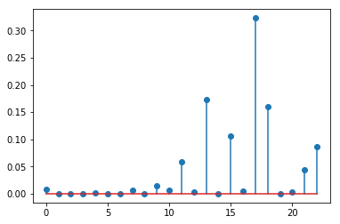

```python
print('True class: ', test_labels[512])
print('Predicted class:', ly_pred[512])
print('Predictions per class:')
print(np.array2string(predictions[512], precision = 2))

plt.stem(predictions[512])
plt.show()
```

The model is not very certain of the answer on a test case

## Conclusion

The models overfitted from the first epoch on. Necessary regularisations and dropouts were tried to reduce this but with not enough effect. The overfitting curve could only be lowered but not removed. The hardest part was to get the first 1D-convolutional model to move at all. It first got stuck at 0.1711 acc and did not train at all no matter what hyperparameters or preprocessing was done. After that I introduced it with smaller learning rate and more complex models with batch normalization and training accuracy started going up. Of course the validation went just down due to overfitting.

Somewhat bad results were bound to happen as the models did not train at all first with smaller networks and after increasing the size they started to heavily overfit. The training sets should have been much larger and some samples like 5000 atleast could have been taken from the test set. The confusion matrix shows that the predictions lack some labels in general which shows that the model has trained itself on a bad direction.

More training data and more preprocessing maybe could help this. I tried dictionary sizes of 10000, 20000 and 25000 and the smallest trained the fastest without causing problems. Also sample words were tried with 50,80,100,120,200 and 80 seems to work just as well as others. Also the samples mostly only included less than 100 words and some forums suggested the lack of training to be due to zero padding. Maybe the word vectors could be checked as there were 30 000 unique tokens, some of them might be the same with just random noise in them as ' or , or " markings.

I will get back to this problem in the future as this was very tricky. Text analysis is anyway a very interesting problem that I would like to tackle.